Restarted 'Python 3.10.5 64-bit' kernel

# About

This code is a case study available on kaggle (aimed at illustrating statistics)

### Case study - Stack Overlfow Annual Developer Survey results

### Agenda of this Case Study:

Derive insights from the data, in doing so we will learn to use python to fetch, manipulate, see and understand data, and, get familiar with some common python libraries and functions we use for EDA

### Context of the dataset we are going to use:

Each year, we at Stack Overflow ask the developer community about everything from their favorite technologies to their job preferences. This year marks the eighth year we’ve published our Annual Developer Survey results—with the largest number of respondents yet. Over 100,000 developers took the 30-minute survey in January 2018.

This year, we covered a few new topics ranging from artificial intelligence to ethics in coding. We also found that underrepresented groups in tech responded to our survey at even lower rates than we would expect from their participation in the workforce. Want to dive into the results yourself and see what you can learn about salaries or machine learning or diversity in tech? We look forward to seeing what you find!

### Content:

This 2018 Developer Survey results are organized on Kaggle in two tables:

`survey_results_public` contains the main survey results, one respondent per row and one column per question

`survey_results_schema` contains each column name from the main results along with the question text corresponding to that column

There are 98,855 responses in this public data release. These responses are what we consider “qualified” for analytical purposes based on completion and time spent on the survey and included at least one non-PII question. Approximately 20,000 responses were started but not included here because respondents did not answer enough questions, or only answered questions with personally identifying information. Of the qualified responses, 67,441 completed the entire survey.

# Libraries

```python
%matplotlib inline
import numpy as np
import pandas as pd
from matplotlib import pyplot as plt
import seaborn as sns
```

# Read dataset

if the dataset `survey_results_public.csv` is not available in the input files then it can be downloaded easily from the kaggle page: https://www.kaggle.com/datasets/stackoverflow/stack-overflow-2018-developer-survey?select=survey_results_public.csv

```python
df = pd.read_csv('../01_InFiles/survey_results_public.csv')
questions = pd.read_csv('../01_InFiles/survey_results_schema.csv')
```

```python
print(df.shape)
df.head()
```

```
(98855, 129)
```

|  | Respondent | Hobby | OpenSource | Country | Student | Employment | FormalEducation | UndergradMajor | CompanySize | DevType | ... | Exercise | Gender | SexualOrientation | EducationParents | RaceEthnicity | Age | Dependents | MilitaryUS | SurveyTooLong | SurveyEasy |
| --- | --- | --- | --- | --- | --- | --- | --- | --- | --- | --- | --- | --- | --- | --- | --- | --- | --- | --- | --- | --- | --- |
| 0 | 1 | Yes | No | Kenya | No | Employed part-time | Bachelor’s degree (BA, BS, B.Eng., etc.) | Mathematics or statistics | 20 to 99 employees | Full-stack developer | ... | 3 - 4 times per week | Male | Straight or heterosexual | Bachelor’s degree (BA, BS, B.Eng., etc.) | Black or of African descent | 25 - 34 years old | Yes | NaN | The survey was an appropriate length | Very easy |
| 1 | 3 | Yes | Yes | United Kingdom | No | Employed full-time | Bachelor’s degree (BA, BS, B.Eng., etc.) | A natural science (ex. biology, chemistry, phy... | 10,000 or more employees | Database administrator;DevOps specialist;Full-... | ... | Daily or almost every day | Male | Straight or heterosexual | Bachelor’s degree (BA, BS, B.Eng., etc.) | White or of European descent | 35 - 44 years old | Yes | NaN | The survey was an appropriate length | Somewhat easy |
| 2 | 4 | Yes | Yes | United States | No | Employed full-time | Associate degree | Computer science, computer engineering, or sof... | 20 to 99 employees | Engineering manager;Full-stack developer | ... | NaN | NaN | NaN | NaN | NaN | NaN | NaN | NaN | NaN | NaN |
| 3 | 5 | No | No | United States | No | Employed full-time | Bachelor’s degree (BA, BS, B.Eng., etc.) | Computer science, computer engineering, or sof... | 100 to 499 employees | Full-stack developer | ... | I don't typically exercise | Male | Straight or heterosexual | Some college/university study without earning ... | White or of European descent | 35 - 44 years old | No | No | The survey was an appropriate length | Somewhat easy |
| 4 | 7 | Yes | No | South Africa | Yes, part-time | Employed full-time | Some college/university study without earning ... | Computer science, computer engineering, or sof... | 10,000 or more employees | Data or business analyst;Desktop or enterprise... | ... | 3 - 4 times per week | Male | Straight or heterosexual | Some college/university study without earning ... | White or of European descent | 18 - 24 years old | Yes | NaN | The survey was an appropriate length | Somewhat easy |

5 rows × 129 columns

# Notes

# Correcting warning in reading dataset

```python
df = pd.read_csv('../01_InFiles/survey_results_public.csv', low_memory = False)
```

# Notes

- Most warnings are often harmless but it is necessary to be cognizant of the same
- The way to deal with these warnings is often documented in the library that we use

# Explore *survey schema data*

```python
questions.head(20)
```

|  | Column | QuestionText |
| --- | --- | --- |
| 0 | Respondent | Randomized respondent ID number (not in order ... |
| 1 | Hobby | Do you code as a hobby? |
| 2 | OpenSource | Do you contribute to open source projects? |
| 3 | Country | In which country do you currently reside? |
| 4 | Student | Are you currently enrolled in a formal, degree... |
| 5 | Employment | Which of the following best describes your cur... |
| 6 | FormalEducation | Which of the following best describes the high... |
| 7 | UndergradMajor | You previously indicated that you went to a co... |
| 8 | CompanySize | Approximately how many people are employed by ... |
| 9 | DevType | Which of the following describe you? Please se... |
| 10 | YearsCoding | Including any education, for how many years ha... |
| 11 | YearsCodingProf | For how many years have you coded professional... |
| 12 | JobSatisfaction | How satisfied are you with your current job? I... |
| 13 | CareerSatisfaction | Overall, how satisfied are you with your caree... |
| 14 | HopeFiveYears | Which of the following best describes what you... |
| 15 | JobSearchStatus | Which of the following best describes your cur... |
| 16 | LastNewJob | When was the last time that you took a job wit... |
| 17 | AssessJob1 | Imagine that you are assessing a potential job... |
| 18 | AssessJob2 | Imagine that you are assessing a potential job... |
| 19 | AssessJob3 | Imagine that you are assessing a potential job... |

# Notes

- We can see how the table is structured
- Each column in df is essentially a question and the column name is an alias for that question
- We can see any question in its entirety by fetching it from the questions dataframe

# Fetch a question's text

```python
questions.loc[4,'QuestionText']
```

```
'Are you currently enrolled in a formal, degree-granting college or university program?'
```

# Notes

- We used `.loc[ ]` to fetch a specific value from the dataframe
- But what if we did not know the position of a certain column name whose question we want to fetch?

# Using question alias to fetch the text

Set question alias as the index so that we can use the questions' alias to fetch the text using through the `.loc[]`

```python
questions.set_index('Column', inplace=True)
questions.head()
```

| Column | QuestionText |
| --- | --- |
| Respondent | Randomized respondent ID number (not in order ... |
| Hobby | Do you code as a hobby? |
| OpenSource | Do you contribute to open source projects? |
| Country | In which country do you currently reside? |
| Student | Are you currently enrolled in a formal, degree... |

```python
# Example fetch
questions.loc['Student', 'QuestionText']
```

```
'Are you currently enrolled in a formal, degree-granting college or university program?'
```

# Basic info of the df

```python
df.info()
```

```
<class 'pandas.core.frame.DataFrame'>
RangeIndex: 98855 entries, 0 to 98854
Columns: 129 entries, Respondent to SurveyEasy
dtypes: float64(41), int64(1), object(87)
memory usage: 97.3+ MB
```

# Notes

- Of the 129 columns, 41 are float type, 1 is integer type and the rest 87 are object type data
- We have 98855 rows in total
- And the amount of memory this dataset is occupying on the RAM is 97.3MB

# Count the number of NaNs

```python
df.isna()
```

|  | Respondent | Hobby | OpenSource | Country | Student | Employment | FormalEducation | UndergradMajor | CompanySize | DevType | ... | Exercise | Gender | SexualOrientation | EducationParents | RaceEthnicity | Age | Dependents | MilitaryUS | SurveyTooLong | SurveyEasy |
| --- | --- | --- | --- | --- | --- | --- | --- | --- | --- | --- | --- | --- | --- | --- | --- | --- | --- | --- | --- | --- | --- |
| 0 | False | False | False | False | False | False | False | False | False | False | ... | False | False | False | False | False | False | False | True | False | False |
| 1 | False | False | False | False | False | False | False | False | False | False | ... | False | False | False | False | False | False | False | True | False | False |
| 2 | False | False | False | False | False | False | False | False | False | False | ... | True | True | True | True | True | True | True | True | True | True |
| 3 | False | False | False | False | False | False | False | False | False | False | ... | False | False | False | False | False | False | False | False | False | False |
| 4 | False | False | False | False | False | False | False | False | False | False | ... | False | False | False | False | False | False | False | True | False | False |
| ... | ... | ... | ... | ... | ... | ... | ... | ... | ... | ... | ... | ... | ... | ... | ... | ... | ... | ... | ... | ... | ... |
| 98850 | False | False | False | False | True | True | True | True | True | True | ... | True | True | True | True | True | True | True | True | True | True |
| 98851 | False | False | False | False | False | False | True | True | True | False | ... | True | True | True | True | True | True | True | True | True | True |
| 98852 | False | False | False | False | False | False | False | True | True | True | ... | True | True | True | True | True | True | True | True | True | True |
| 98853 | False | False | False | False | False | False | False | True | True | True | ... | True | True | True | True | True | True | True | True | True | True |
| 98854 | False | False | False | False | True | True | True | True | True | True | ... | True | True | True | True | True | True | True | True | True | True |

98855 rows × 129 columns

```python
df.isna().apply(pd.value_counts)
```

|  | Respondent | Hobby | OpenSource | Country | Student | Employment | FormalEducation | UndergradMajor | CompanySize | DevType | ... | Exercise | Gender | SexualOrientation | EducationParents | RaceEthnicity | Age | Dependents | MilitaryUS | SurveyTooLong | SurveyEasy |
| --- | --- | --- | --- | --- | --- | --- | --- | --- | --- | --- | --- | --- | --- | --- | --- | --- | --- | --- | --- | --- | --- |
| False | 98855.0 | 98855.0 | 98855.0 | 98443 | 94901 | 95321 | 94703 | 79036 | 71531 | 92098 | ... | 72108 | 64469 | 59765 | 61813 | 57473 | 64574 | 62596 | 15781 | 65941 | 65879 |
| True | NaN | NaN | NaN | 412 | 3954 | 3534 | 4152 | 19819 | 27324 | 6757 | ... | 26747 | 34386 | 39090 | 37042 | 41382 | 34281 | 36259 | 83074 | 32914 | 32976 |

2 rows × 129 columns

# Notes

- Treating missing values is beyond the scope of this notebook, hence we will ignore it for now

# Top countries according to userbase

```python
# Listing all columns
np.array(df.columns)
```

```
array(['Respondent', 'Hobby', 'OpenSource', 'Country', 'Student',
       'Employment', 'FormalEducation', 'UndergradMajor', 'CompanySize',
       'DevType', 'YearsCoding', 'YearsCodingProf', 'JobSatisfaction',
       'CareerSatisfaction', 'HopeFiveYears', 'JobSearchStatus',
       'LastNewJob', 'AssessJob1', 'AssessJob2', 'AssessJob3',
       'AssessJob4', 'AssessJob5', 'AssessJob6', 'AssessJob7',
       'AssessJob8', 'AssessJob9', 'AssessJob10', 'AssessBenefits1',
       'AssessBenefits2', 'AssessBenefits3', 'AssessBenefits4',
       'AssessBenefits5', 'AssessBenefits6', 'AssessBenefits7',
       'AssessBenefits8', 'AssessBenefits9', 'AssessBenefits10',
       'AssessBenefits11', 'JobContactPriorities1',
       'JobContactPriorities2', 'JobContactPriorities3',
       'JobContactPriorities4', 'JobContactPriorities5',
       'JobEmailPriorities1', 'JobEmailPriorities2',
       'JobEmailPriorities3', 'JobEmailPriorities4',
       'JobEmailPriorities5', 'JobEmailPriorities6',
       'JobEmailPriorities7', 'UpdateCV', 'Currency', 'Salary',
       'SalaryType', 'ConvertedSalary', 'CurrencySymbol',
       'CommunicationTools', 'TimeFullyProductive', 'EducationTypes',
       'SelfTaughtTypes', 'TimeAfterBootcamp', 'HackathonReasons',
       'AgreeDisagree1', 'AgreeDisagree2', 'AgreeDisagree3',
       'LanguageWorkedWith', 'LanguageDesireNextYear',
       'DatabaseWorkedWith', 'DatabaseDesireNextYear',
       'PlatformWorkedWith', 'PlatformDesireNextYear',
       'FrameworkWorkedWith', 'FrameworkDesireNextYear', 'IDE',
       'OperatingSystem', 'NumberMonitors', 'Methodology',
       'VersionControl', 'CheckInCode', 'AdBlocker', 'AdBlockerDisable',
       'AdBlockerReasons', 'AdsAgreeDisagree1', 'AdsAgreeDisagree2',
       'AdsAgreeDisagree3', 'AdsActions', 'AdsPriorities1',
       'AdsPriorities2', 'AdsPriorities3', 'AdsPriorities4',
       'AdsPriorities5', 'AdsPriorities6', 'AdsPriorities7',
       'AIDangerous', 'AIInteresting', 'AIResponsible', 'AIFuture',
       'EthicsChoice', 'EthicsReport', 'EthicsResponsible',
       'EthicalImplications', 'StackOverflowRecommend',
       'StackOverflowVisit', 'StackOverflowHasAccount',
       'StackOverflowParticipate', 'StackOverflowJobs',
       'StackOverflowDevStory', 'StackOverflowJobsRecommend',
       'StackOverflowConsiderMember', 'HypotheticalTools1',
       'HypotheticalTools2', 'HypotheticalTools3', 'HypotheticalTools4',
       'HypotheticalTools5', 'WakeTime', 'HoursComputer', 'HoursOutside',
       'SkipMeals', 'ErgonomicDevices', 'Exercise', 'Gender',
       'SexualOrientation', 'EducationParents', 'RaceEthnicity', 'Age',
       'Dependents', 'MilitaryUS', 'SurveyTooLong', 'SurveyEasy'],
      dtype=object)
```

```python
# Get top 10 countries according to userbase
df.Country.value_counts().head(10)
```

```
United States         20309
India                 13721
Germany                6459
United Kingdom         6221
Canada                 3393
Russian Federation     2869
France                 2572
Brazil                 2505
Poland                 2122
Australia              2018
Name: Country, dtype: int64
```

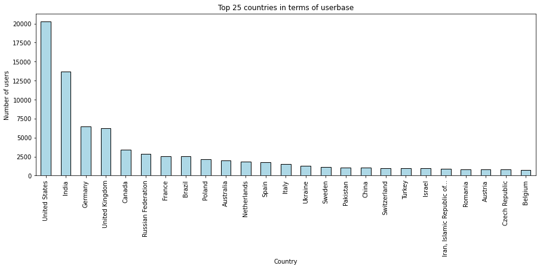

```python
# Barplot of above stats for top 25 countries
df.Country.value_counts().head(25).plot(kind = 'bar', edgecolor = 'black', color = 'lightblue', figsize = (15,5))
plt.xlabel('Country')
plt.ylabel('Number of users')
plt.title('Top 25 countries in terms of userbase')
plt.show()
```

# Selecting only the rows of top 25 countries

```python
# List of top 25 countries
df.Country.value_counts().head(25).index
```

```
Index(['United States', 'India', 'Germany', 'United Kingdom', 'Canada',
       'Russian Federation', 'France', 'Brazil', 'Poland', 'Australia',
       'Netherlands', 'Spain', 'Italy', 'Ukraine', 'Sweden', 'Pakistan',
       'China', 'Switzerland', 'Turkey', 'Israel',
       'Iran, Islamic Republic of...', 'Romania', 'Austria', 'Czech Republic',
       'Belgium'],
      dtype='object')
```

```python
# Checking for each entry of the df if its in the above list
df.Country.isin(df.Country.value_counts().head(25).index)
```

```
0        False
1         True
2         True
3         True
4        False
         ...
98850     True
98851     True
98852     True
98853     True
98854    False
Name: Country, Length: 98855, dtype: bool
```

```python
# Using logical indexing to get the df rows with only 'True' i.e. the rows which correspond to the countries in the top 25 countries list
df.loc[df.Country.isin(df.Country.value_counts().head(25).index), :]
```

|  | Respondent | Hobby | OpenSource | Country | Student | Employment | FormalEducation | UndergradMajor | CompanySize | DevType | ... | Exercise | Gender | SexualOrientation | EducationParents | RaceEthnicity | Age | Dependents | MilitaryUS | SurveyTooLong | SurveyEasy |
| --- | --- | --- | --- | --- | --- | --- | --- | --- | --- | --- | --- | --- | --- | --- | --- | --- | --- | --- | --- | --- | --- |
| 1 | 3 | Yes | Yes | United Kingdom | No | Employed full-time | Bachelor’s degree (BA, BS, B.Eng., etc.) | A natural science (ex. biology, chemistry, phy... | 10,000 or more employees | Database administrator;DevOps specialist;Full-... | ... | Daily or almost every day | Male | Straight or heterosexual | Bachelor’s degree (BA, BS, B.Eng., etc.) | White or of European descent | 35 - 44 years old | Yes | NaN | The survey was an appropriate length | Somewhat easy |
| 2 | 4 | Yes | Yes | United States | No | Employed full-time | Associate degree | Computer science, computer engineering, or sof... | 20 to 99 employees | Engineering manager;Full-stack developer | ... | NaN | NaN | NaN | NaN | NaN | NaN | NaN | NaN | NaN | NaN |
| 3 | 5 | No | No | United States | No | Employed full-time | Bachelor’s degree (BA, BS, B.Eng., etc.) | Computer science, computer engineering, or sof... | 100 to 499 employees | Full-stack developer | ... | I don't typically exercise | Male | Straight or heterosexual | Some college/university study without earning ... | White or of European descent | 35 - 44 years old | No | No | The survey was an appropriate length | Somewhat easy |
| 5 | 8 | Yes | No | United Kingdom | No | Employed full-time | Bachelor’s degree (BA, BS, B.Eng., etc.) | Computer science, computer engineering, or sof... | 10 to 19 employees | Back-end developer;Database administrator;Fron... | ... | 1 - 2 times per week | Male | Straight or heterosexual | Secondary school (e.g. American high school, G... | White or of European descent | 18 - 24 years old | No | NaN | The survey was an appropriate length | Somewhat easy |
| 6 | 9 | Yes | Yes | United States | No | Employed full-time | Some college/university study without earning ... | Computer science, computer engineering, or sof... | 10,000 or more employees | Back-end developer;Front-end developer;Full-st... | ... | I don't typically exercise | Male | Straight or heterosexual | Master’s degree (MA, MS, M.Eng., MBA, etc.) | White or of European descent | 18 - 24 years old | No | No | The survey was an appropriate length | Somewhat easy |
| ... | ... | ... | ... | ... | ... | ... | ... | ... | ... | ... | ... | ... | ... | ... | ... | ... | ... | ... | ... | ... | ... |
| 98849 | 101478 | No | Yes | India | No | Employed full-time | Bachelor’s degree (BA, BS, B.Eng., etc.) | NaN | NaN | NaN | ... | NaN | NaN | NaN | NaN | NaN | NaN | NaN | NaN | NaN | NaN |
| 98850 | 101513 | Yes | Yes | United States | NaN | NaN | NaN | NaN | NaN | NaN | ... | NaN | NaN | NaN | NaN | NaN | NaN | NaN | NaN | NaN | NaN |
| 98851 | 101531 | No | Yes | Spain | Yes, full-time | Not employed, but looking for work | NaN | NaN | NaN | Back-end developer;Front-end developer | ... | NaN | NaN | NaN | NaN | NaN | NaN | NaN | NaN | NaN | NaN |
| 98852 | 101541 | Yes | Yes | India | Yes, full-time | Employed full-time | Bachelor’s degree (BA, BS, B.Eng., etc.) | NaN | NaN | NaN | ... | NaN | NaN | NaN | NaN | NaN | NaN | NaN | NaN | NaN | NaN |
| 98853 | 101544 | Yes | No | Russian Federation | No | Independent contractor, freelancer, or self-em... | Some college/university study without earning ... | NaN | NaN | NaN | ... | NaN | NaN | NaN | NaN | NaN | NaN | NaN | NaN | NaN | NaN |

78910 rows × 129 columns

```python
# Store this info in a variable
top25 = df.loc[df.Country.isin(df.Country.value_counts().head(25).index), :]
```

# Plot

```python
# See what `pd.crosstab` shows
```

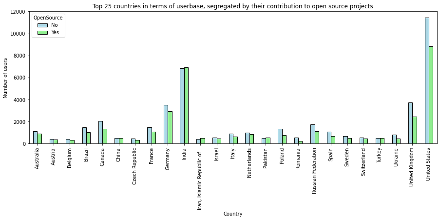

```python
# Generate the plot for the count of 'open-source' and 'not open-source' for all the top 25 countries
pd.crosstab(top25.Country, top25.OpenSource).plot(kind = 'bar', edgecolor = 'black', color = ['lightblue', 'lightgreen'], figsize = (15,5))
plt.xlabel('Country')
plt.ylabel('Number of users')
plt.title('Top 25 countries in terms of userbase, segregated by their contribution to open source projects')
plt.show()
```

# Notes

- The green bars indicate the population that contributes to open source projects and the blue indicates the rest
- If we want to the bars to be sorted the same way as the earlier plot, we can index the crosstabdata in that order

# Sort the above plot in the same way as the earlier plot

```python
# The list to be used for sorting the pd.crosstab entries
df.Country.value_counts().head(25).index
```

```
Index(['United States', 'India', 'Germany', 'United Kingdom', 'Canada',
       'Russian Federation', 'France', 'Brazil', 'Poland', 'Australia',
       'Netherlands', 'Spain', 'Italy', 'Ukraine', 'Sweden', 'Pakistan',
       'China', 'Switzerland', 'Turkey', 'Israel',
       'Iran, Islamic Republic of...', 'Romania', 'Austria', 'Czech Republic',
       'Belgium'],
      dtype='object')
```

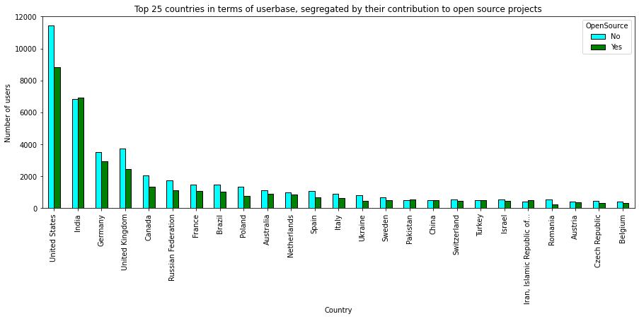

```python
# Plot
pd.crosstab(top25.Country, top25.OpenSource).loc[df.Country.value_counts().head(25).index,:].plot(kind = 'bar', edgecolor = 'black', color = ['cyan', 'green'], figsize = (15,5))
# Labels and title
plt.xlabel('Country')
plt.ylabel('Number of users')
plt.title('Top 25 countries in terms of userbase, segregated by their contribution to open source projects')
plt.show()
```

# Notes

- Proportionally, Indian users seem to be contributing more for open source projects than most other countries
- In case of Turky, the two categories are almost the same
- In case of Iran, the open source contributors are more compared to the ones that don't.